# TAREA DEL MODULO 12 DEEP LEARNING

#### En este cuaderno cubriremos el ajuste fino de un modelo simple en un conjunto de datos personalizado, tomando un modelo previamente entrenado. Cubriremos los siguientes temas:

- Grazzly/black/teddys dataset
- Modelo de la Arquitectura de la Red Neural:
  - VGG16
  - Dense layers
- Generador de imágenes de un directorio
- Prueba de imagenes aleatorias </font> </font>

### El dataset esta compuesto de 240 imagenes de osos repartidas entre: grazzly, black y teddys

#### importamos las librerias correspondientes para poder tener acceso a los archivos

```python
import os
import tensorflow as tf
from tensorflow.keras.preprocessing import image
base_dir = 'B:/polo/'
```

#### Vemos unos ejemplo de las fotos dentro de la carpeta train

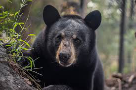

```python
from tensorflow.keras.preprocessing import image
image.load_img('B:/polo/train/black//00000000.jpg')
```

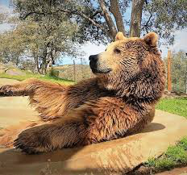

```python
image.load_img('B:/polo/validation/grizzly//00000040.jpg')
```

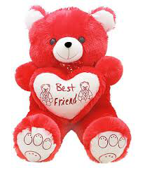

```python
image.load_img('B:/polo/validation/teddys//00000057.jpg')
```

#### Se organizan los datos que vamos a emplear de manera que una parte sirva para entrenar, otra parte como datos de validacion y otra parte para usarlos como evalucion del modelo final que utilicemos. Como se indica en la imagen posterior. los tres conjuntos de imagenes tiene que están balanceadas para garantizar que la Accuracy del modelo pueda ser una metrica valida.

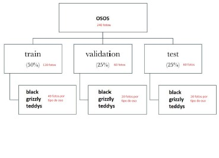

```python
"""
# tf version session setting lines

from tensorflow.python.keras.backend import set_session
from tensorflow.python.keras.models import load_model
import tensorflow as tf

from tensorflow.compat.v1 import ConfigProto
config = ConfigProto()
config.gpu_options.allow_growth = True

sess = tf.Session(config=config)
graph = tf.get_default_graph()

# ¡los modelos deben cargarse DESPUÉS DE CONFIGURAR LA SESIÓN para keras!
# De lo contrario, sus pesos no estarán disponibles en los hilos después de que se haya establecido la sesión

set_session(sess)
"""
```

[output not shown]

## Modelo de la Arquitectura de la Red Neural

#### Construya el modelo para usar una red vgg16 preentrenada sin la última capa, pre-entrenada en imagenet.

Entonces: Agregue una capa de agrupación promedio global después de la estructura pre-entrenada Agregue una capa densa, con 512 unidades y relu activado La capa final será otra completamente conectada con el número de clases y softmax activado.</font>

#### En nuestro ejemplo usaremos la red neuronal VGG16. Dicha red se ha entrenado previamente en un conjunto de datos de ImageNet, que tiene 1.4 millones de imágenes en 1000 clases diferentes. El modelo VGG16 es una red de 16 capas propuesto por Karen Simonyan y Andrew Zisserman. El modelo VGG16, entre otros, viene preempaquetado con Keras. Podemos importarlo desde el módulo keras.application y la podemos representar con la funcion summary. No necesitamos las últimas tres capas (que son el clasificador de VGG16) porque crearemos unas propias para construir nuestro clasificador y predecir el tipo de oso de la imagen a partir del último feature map de forma y tamaño (7, 7, 512) que nos devuelve la base convolucional VGG16.

```python
from keras.applications import MobileNet, VGG16

pre_trained_model = VGG16(input_shape = (224, 224, 3),
include_top = False,
weights = 'imagenet')
```

```
WARNING:tensorflow:From C:\Users\polo\anaconda3\lib\site-packages\tensorflow\python\ops\resource_variable_ops.py:435: colocate_with (from tensorflow.python.framework.ops) is deprecated and will be removed in a future version.
Instructions for updating:
Colocations handled automatically by placer.
```

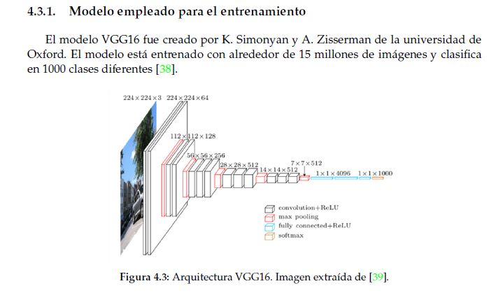

#### La entrada de la red está formada por imágenes con unas dimensiones de 224 x 224 píxeles y 3 canales. La primera capa convolucional utiliza un filtro de profundidad igual al de la imagen de entrada. En su arquitectura se componen de 12 capas convolucionales más, donde el filtro de cada una de estas va acorde con la salida de la capa anterior. Además de las capas convolucionales está formada por 5 capas Max Pooling que se encargan de reducir las dimensiones de la imagen hasta una imagen de 7x7x512 como se observa en la Figura 4.3. La salida está conectada a 2 capas totalmente conectadas de 4096 neuronas y un clasificador para 1000 clases [38].

```python
pre_trained_model.summary()
```

```
Model: "vgg16"
_________________________________________________________________
Layer (type)                 Output Shape              Param #
=================================================================
input_1 (InputLayer)         (None, 224, 224, 3)       0
_________________________________________________________________
block1_conv1 (Conv2D)        (None, 224, 224, 64)      1792
_________________________________________________________________
block1_conv2 (Conv2D)        (None, 224, 224, 64)      36928
_________________________________________________________________
block1_pool (MaxPooling2D)   (None, 112, 112, 64)      0
_________________________________________________________________
block2_conv1 (Conv2D)        (None, 112, 112, 128)     73856
_________________________________________________________________
block2_conv2 (Conv2D)        (None, 112, 112, 128)     147584
_________________________________________________________________
block2_pool (MaxPooling2D)   (None, 56, 56, 128)       0
_________________________________________________________________
block3_conv1 (Conv2D)        (None, 56, 56, 256)       295168
_________________________________________________________________
block3_conv2 (Conv2D)        (None, 56, 56, 256)       590080
_________________________________________________________________
block3_conv3 (Conv2D)        (None, 56, 56, 256)       590080
_________________________________________________________________
block3_pool (MaxPooling2D)   (None, 28, 28, 256)       0
_________________________________________________________________
block4_conv1 (Conv2D)        (None, 28, 28, 512)       1180160
_________________________________________________________________
block4_conv2 (Conv2D)        (None, 28, 28, 512)       2359808
_________________________________________________________________
block4_conv3 (Conv2D)        (None, 28, 28, 512)       2359808
_________________________________________________________________
block4_pool (MaxPooling2D)   (None, 14, 14, 512)       0
_________________________________________________________________
block5_conv1 (Conv2D)        (None, 14, 14, 512)       2359808
_________________________________________________________________
block5_conv2 (Conv2D)        (None, 14, 14, 512)       2359808
_________________________________________________________________
block5_conv3 (Conv2D)        (None, 14, 14, 512)       2359808
_________________________________________________________________
block5_pool (MaxPooling2D)   (None, 7, 7, 512)         0
=================================================================
Total params: 14,714,688
Trainable params: 14,714,688
Non-trainable params: 0
_________________________________________________________________
```

#### Importamos las librerias que vamos a necesitar para la construccion de la Red Neuronal solicitada:

#### Partimos de la base del modelo de VGG16, a la que complementamos con una capa GlobalAveragePooling2D, una capa Densa de 512 y activacion relu y otra capa densa de prediccion con activacion softmax.

```python
import pandas as pd
import numpy as np
import os
import keras

from keras.layers import Dense,GlobalAveragePooling2D
from keras.applications import MobileNet, VGG16

# base_model=MobileNet(weights='imagenet',include_top=False) # importa el modelo de mobilenet y descarta la última capa.

base_model=VGG16(input_shape = (224, 224, 3),
                 weights='imagenet',
                 include_top=False) # importa el modelo vgg16 y descarta la última capa.

x=base_model.output
x=GlobalAveragePooling2D()(x)
x=Dense(512,activation='relu')(x) # dense layer 3
preds=Dense(3,activation='softmax')(x) # final layer with softmax activation
```

```python
from keras.models import Model
```

```python
model=Model(inputs=base_model.input, outputs=preds)
model.summary()
```

```
Model: "model_1"
_________________________________________________________________
Layer (type)                 Output Shape              Param #
=================================================================
input_2 (InputLayer)         (None, 224, 224, 3)       0
_________________________________________________________________
block1_conv1 (Conv2D)        (None, 224, 224, 64)      1792
_________________________________________________________________
block1_conv2 (Conv2D)        (None, 224, 224, 64)      36928
_________________________________________________________________
block1_pool (MaxPooling2D)   (None, 112, 112, 64)      0
_________________________________________________________________
block2_conv1 (Conv2D)        (None, 112, 112, 128)     73856
_________________________________________________________________
block2_conv2 (Conv2D)        (None, 112, 112, 128)     147584
_________________________________________________________________
block2_pool (MaxPooling2D)   (None, 56, 56, 128)       0
_________________________________________________________________
block3_conv1 (Conv2D)        (None, 56, 56, 256)       295168
_________________________________________________________________
block3_conv2 (Conv2D)        (None, 56, 56, 256)       590080
_________________________________________________________________
block3_conv3 (Conv2D)        (None, 56, 56, 256)       590080
_________________________________________________________________
block3_pool (MaxPooling2D)   (None, 28, 28, 256)       0
_________________________________________________________________
block4_conv1 (Conv2D)        (None, 28, 28, 512)       1180160
_________________________________________________________________
block4_conv2 (Conv2D)        (None, 28, 28, 512)       2359808
_________________________________________________________________
block4_conv3 (Conv2D)        (None, 28, 28, 512)       2359808
_________________________________________________________________
block4_pool (MaxPooling2D)   (None, 14, 14, 512)       0
_________________________________________________________________
block5_conv1 (Conv2D)        (None, 14, 14, 512)       2359808
_________________________________________________________________
block5_conv2 (Conv2D)        (None, 14, 14, 512)       2359808
_________________________________________________________________
block5_conv3 (Conv2D)        (None, 14, 14, 512)       2359808
_________________________________________________________________
block5_pool (MaxPooling2D)   (None, 7, 7, 512)         0
_________________________________________________________________
global_average_pooling2d_1 ( (None, 512)               0
_________________________________________________________________
dense_1 (Dense)              (None, 512)               262656
_________________________________________________________________
dense_2 (Dense)              (None, 3)                 1539
=================================================================
Total params: 14,978,883
Trainable params: 14,978,883
Non-trainable params: 0
_________________________________________________________________
```

#### Establezca las primeras 19 capas en no entrenables y el resto en entrenables.

```python
len (base_model.layers)
```

```
19
```

```python
len(model.layers)
```

```
22
```

```python
for layer in model.layers[:19]:
    layer.trainable=False
for layer in model.layers[19:]:
    layer.trainable=True
```

#### **En este punto, pasamos a la preparación de las imagines que consistiría en el cambiar el tamaño y la escala de píxeles.**

**Hemos realizado dos modelos, el primero no lo vamos a ejecutar y es a nivel informativo.**

```python
"""base_dir = 'B:/polo/'

train_dir = os.path.join(base_dir, 'train')
validation_dir = os.path.join(base_dir, 'validation')
test_dir = os.path.join(base_dir, 'test')

# Directorio con las imagenes de training
train_black_dir = os.path.join(train_dir, 'black')
train_grizzly_dir = os.path.join(train_dir, 'grizzly')
train_teddys_dir = os.path.join(train_dir, 'teddys')

# Directorio con las imagenes de validation
validation_black_dir = os.path.join(validation_dir, 'black')
validation_grizzly_dir = os.path.join(validation_dir, 'grizzly')
validation_teddys_dir = os.path.join(validation_dir, 'teddys')

# Directorio con las imagenes de test
test_black_dir = os.path.join(test_dir, 'black')
test_grizzly_dir = os.path.join(test_dir, 'grizzly')
test_teddys_dir = os.path.join(test_dir, 'teddys')

from tensorflow.keras.applications import VGG16
pre_trained_model = VGG16(input_shape = (224, 224, 3),
        include_top = False,
        weights = 'imagenet')

pre_trained_model.trainable = True

set_trainable = False

for layer in pre_trained_model.layers:
    if layer.name == 'block5_conv1':
        set_trainable = True
    if set_trainable:
        layer.trainable = True
    else:
        layer.trainable = False

##AL PREMODELO DE KERAS SE VAMOS SUMANDO LAS CAPAS DEL EJERCICIO

modelFT = tf.keras.models.Sequential([
    pre_trained_model,
    tf.keras.layers.GlobalAveragePooling2D(),
    tf.keras.layers.Dense(512,activation='relu'),
    tf.keras.layers.Dense(3,activation='softmax')
])

modelFT.summary()"""
```

[output not shown]

**Este código se corresponde con la parte enseñada en la practica correspondoiente del curso pero ampliada a las tres categorias (train, validation y test) de imagenes.** </font>

```python
from keras.preprocessing.image import ImageDataGenerator
from keras.applications.mobilenet import preprocess_input as preprocess_mobilenet
from keras.applications.vgg16 import preprocess_input as preprocess_vgg16

# train_datagen=ImageDataGenerator(preprocessing_function=preprocess_mobilenet)  #incluido en nuestras dependencias
train_datagen=ImageDataGenerator(preprocessing_function=preprocess_vgg16)
train_generator=train_datagen.flow_from_directory('B:/polo/train',
                                                  # aquí es donde especifica la ruta a la carpeta de datos principal
                                                  target_size=(224, 224),
                                                  # default parameters
                                                  color_mode='rgb',
                                                  batch_size=12,
                                                  class_mode='categorical',
                                                  shuffle=True)
validation_datagen=ImageDataGenerator(preprocessing_function=preprocess_vgg16)
validation_generator=validation_datagen.flow_from_directory('B:/polo/validation',
                                                  # aquí es donde especifica la ruta a la carpeta de datos principal
                                                  target_size=(224, 224),
                                                  # default parameters
                                                  color_mode='rgb',
                                                  batch_size=12,
                                                  class_mode='categorical',
                                                  shuffle=True)
test_datagen=ImageDataGenerator(preprocessing_function=preprocess_vgg16)
test_generator=test_datagen.flow_from_directory('B:/polo/test',
                                                  # aquí es donde especifica la ruta a la carpeta de datos principal
                                                target_size=(224, 224),
                                                  # default parameters
                                                  color_mode='rgb',
                                                  batch_size=12,
                                                  class_mode='categorical',
                                                  shuffle=True)
```

```
Found 120 images belonging to 3 classes.
Found 60 images belonging to 3 classes.
Found 60 images belonging to 3 classes.
```

Compile el modelo, utilizando adam y Xentropía categórica. Incluya la precisión como una métrica. Entrena al modelo durante 5 épocas. Recuerde incluir el step_size correcto. Sugerencia: use las propiedades del generador .n y .batch_size

**En este momento importamos y cargamos las librerias para otro tipo de presentacion gráfica de la Red Neuronal diseñada según los parámetros indicados y lo guardamos en el archivo model .png**

import pydot import graphviz from tensorflow.keras.utils import plot_model from IPython.display import Image

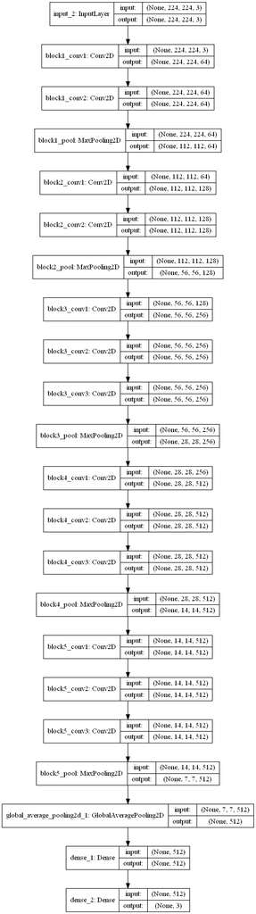

```python
keras.utils.plot_model(model, "model.png", show_shapes = True)
```

plot_model(model, to_file='C:/convnet.png', show_shapes=True, show_layer_names=True) Image(filename='convnet.png')